# 340 Fall 2024 take home midterm solutions

```r
cables = data.frame(
  site = rep(c("Alderwood","Brentwick","Coppergrove"), times=c(53,48,51)),
  flaws = c(6,4,4,1,2,1,4,2,4,3,4,8,2,4,6,2,4,1,2,2,0,2,5,2,3,3,3,2,5,4,4,
            1,4,3,5,4,4,3,3,4,0,3,4,4,3,5,3,2,1,1,2,3,4,2,5,1,2,2,3,1,2,3,
            0,4,2,4,2,2,2,4,4,2,3,5,2,3,2,2,3,1,3,1,1,1,1,0,3,4,4,4,2,2,4,
            3,3,2,1,7,3,1,1,3,6,3,7,4,2,3,1,0,4,1,3,4,8,3,3,1,4,3,3,2,2,3,
            3,1,0,4,6,3,3,3,7,3,4,3,2,2,4,3,1,4,1,5,3,3,2,3,3,1,3,1)
)
```

## Problem 1: Cable flaws (10 points)

Infinity Cable (fictional) manufactures fiber optic cable for industrial purposes. They have three manufacturing facilities, in Alderwood, Brentwick and Coppergrove. A recent quality control audit sampled various 1 kilometer lengths of cable from the three facilities and counted the number of flaws in the cables.

Your job is to perform a comparison using the testing techniques we’ve covered in this course to see if there is evidence that the facilities actually produce cable of different quality. Do not use techniques we have not covered in this course. The data are found in the `cableFlaws.csv` file.

1. (2 points) A colleague suggests that we should focus our attention on a comparison of Alderwood and Brentwick (ignoring Coppergrove), since they seem to have the largest gap in average number of flaws. Why specifically would this not be a good approach?
2. Now you will perform the test. You should
   1. (1 point) State your null and alternative hypotheses,
   2. (1 point) decide on the test statistic to use,
   3. (1 point) state whether this is a one or two-sided test, and explain why,
   4. (2 points) produce a simulated distribution for your test statistic under the null hypothesis
   5. (2 points) calculate the $p$-value and
   6. (1 point) make your conclusion.

*Hint: your test statistic should somehow compare all 3 groups. There are many possible statistics you could use. If you are stuck consider a statistic based on the site means or the site variances.*

**SOLUTION**

1. If we selectively ignore Coppergrove we will be cherry-picking data. You could call this selection bias as well. This will lead us to potentially find a ‘significant’ result by ignoring the variability of the other site. Essentially we’re performing multiple tests and only keeping the one result that gives us a low p-value. You could call this p-hacking. The main consequence is an increased risk of Type 1 error.

b.i. $H_0$: all facilities produce cable of the same quality; $H_A$: not all facilities produce cable of the same quality.

You could also express this in terms of the mean number of flaws: $H_0: \mu_A = \mu_B=\mu_C$ vs $H_A:$ at least one mean differs.

It is important that the hypotheses be statements about the populations (i.e. facilities) and not statements about evidence, data, or significance.

Also the alternative should not be stated as $\mu_A \not= \mu_B \not=\mu_C$. It is not required that all means differ, only that one of them does.

b.ii. There are **many good test statistics to use.**

**Bad statistics to use:**

- Mean of means $\bar{X}_1 + \bar{X}_2 + \bar{X}_3$
- Variance of variances: $Var(S^2_1, S^2_2, S^2_3)$
- Comparing Max variance to min variance: e.g. $max(S^2_1, S^2_2, S^2_3)-min(S^2_1, S^2_2, S^2_3)$ or $\dfrac{max(S^2_1, S^2_2, S^2_3)}{min(S^2_1, S^2_2, S^2_3)}$
- An unbalanced statistic, e.g. $|\bar{X}_1-\bar{X}_2|+ |\bar{X}_2-\bar{X}_3|$ or $\bar{X}_1 - \bar{X}_2 -\bar{X}_3$ or $\left|\bar{X}_1 - \bar{X}_2 -\bar{X}_3\right|$ or $(\bar{X}_1-\bar{X}_3)+(\bar{X}_3-\bar{X}_2)=\bar{X}_1-\bar{X}_2$
- A Chi squared test (not appropriate because of the low frequency in the cells and moreover not a method we use in this course)

b.iv. One method one could use is a Monte Carlo approach where we assume that the number of flaws from each site comes from a Poisson distribution. If we do that, under the null hypothesis the rate parameter would need to be fit:

```r
lambda.hat <- mean(cables$flaws)
```

Then on each replicate of the Monte Carlo we’d have to generate a new sample using this common lambda. Alternatively we could use a permutation test. This does not assume any particular population model, but rather we just shuffle the data around on each replicate. Both methods work, the permutation test method is perhaps more robust since it does not rely on an assumption of the population shape.

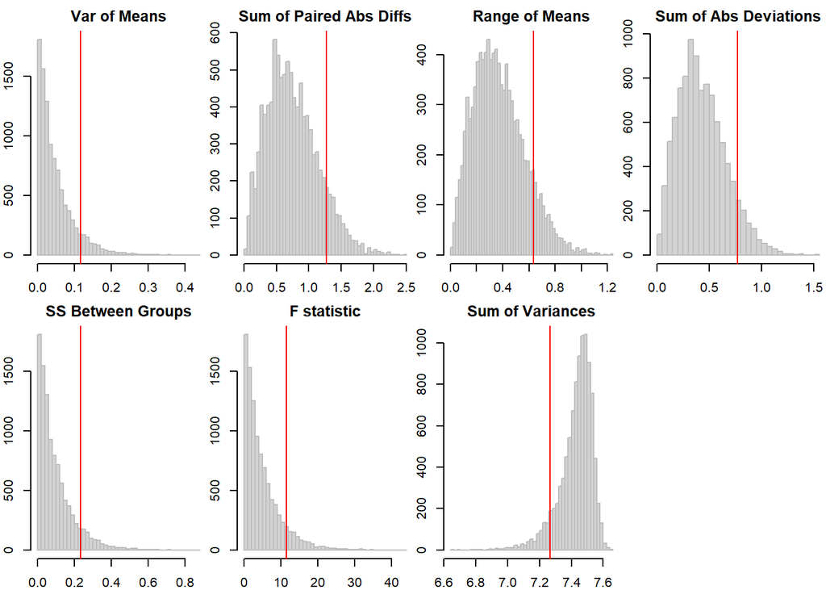

```r
set.seed(1)
NMC <- 10000

#test statistics
t.stats <- c("Var of Means",
             "Sum of Paired Abs Diffs",
             "Range of Means",
             "Sum of Abs Deviations",
             "SS Between Groups",
             "F statistic",
             "Sum of Variances")

var.means <- numeric(NMC)
sum.abs.diffs <- numeric(NMC)
rng.means <- numeric(NMC)
sum.abs.devs <- numeric(NMC)
SSbetw <- numeric(NMC)
Fstat <- numeric(NMC)
sum.vars <- numeric(NMC)

test.stat<-function(df, type){
  means <- aggregate(flaws~site, df, FUN="mean")$flaws
  mean.overall <- mean(df$flaws)
  if(type==1){
    test.stat <- var(aggregate(flaws~site, df, FUN="mean")$flaws)
  } else if(type==2){
    means[length(means)+1]<-means[1]
    test.stat <- sum(abs(diff(means)))
  } else if(type==3){
    test.stat <- diff(range(aggregate(flaws~site, df, FUN="mean")$flaws))
  } else if(type==4){
    test.stat <- sum(abs(means-mean.overall))
  } else if(type==5){
    test.stat <- sum((means-mean.overall)^2)
  } else if(type==6){
    test.stat <- anova(lm(flaws~site, df))$"Sum Sq"[1]
  } else if(type==7){
    test.stat <- sum(aggregate(flaws~site, df, FUN="var")$flaws)
  } else if(type==8){
    test.stat <- sum(aggregate(flaws~site, df, FUN="max")$flaws-aggregate(flaws~site, df, FUN="min")$flaws)
  }
  return(test.stat)
}

obs.t <- 0
for(i in 1:7){obs.t[i] <- test.stat(cables, i)}

sim.t <- data.frame(var.means,
                    sum.abs.diffs,
                    rng.means,
                    sum.abs.devs,
                    SSbetw,
                    Fstat,
                    sum.vars)
for(i in 1:NMC){
  shufdf <- cables; shufdf$flaws <- sample(cables$flaws)
  for(j in 1:7){sim.t[i,j] <- test.stat(shufdf,j)}
}

p.vals <- 0
for(i in 1:6){ p.vals[i] <- mean(sim.t[,i]>=obs.t[i])}
p.vals[7] <- mean(sim.t[,7]<=obs.t[7])

par(mfrow=c(2,4))
par(mar=c(2,2,2,0))
for(i in 1:7){
#  hist_breaks <- hist(sim.t[,i], breaks=50)$breaks
#  color_list <- rep("gray", length(hist_breaks))
#  if(i != 7){color_list[hist_breaks >= obs.t[i]] <- "red"} else {color_list[hist_breaks <= obs.t[i]] <- "red"}
#  hist(sim.t[,i], main=t.stats[i], breaks=50, border="gray", xlab="", ylab="", col=color_list);
  hist(sim.t[,i], main=t.stats[i], breaks=50, border="gray", xlab="", ylab="");
  abline(v=obs.t[i], col="red")
}
```

b.v.

```r
results <- data.frame(t.stats, obs.t, p.vals)
names(results) <- c("Test Statisitc","Observed Value","p-value")
results
```

```
##            Test Statisitc Observed Value p-value
## 1            Var of Means      0.1171409  0.0923
## 2 Sum of Paired Abs Diffs      1.2680818  0.1052
## 3          Range of Means      0.6340409  0.1052
## 4   Sum of Abs Deviations      0.7720698  0.0830
## 5       SS Between Groups      0.2346394  0.0923
## 6             F statistic     11.5881075  0.0978
## 7        Sum of Variances      7.2650874  0.0784
```

*(Note: The data was in fact generated from Poisson distributions with rates $\lambda_A=3, \lambda_B=2.2, \lambda_C=3.2$.)* No matter what test you use, however, you’d likely get a $p$-value between .07 and .11.

b.vi. Regardless of which test statistic you used it is most likely that you fail to get a $p$-value $<0.05$. Thus you would conclude that you fail to find significance evidence against the null - we lack evidence that the facilities produce cables of different quality.

This does not mean that we have proven the null hypothesis true; we just have failed to find enough evidence to refute the null hypothesis.

## Q2 - Estimation 3,2,3,2pts (Bi)

Let $X_i$ be i.i.d random variables following continuous Uniform($-a,a$) for some unknown positive parameter $a$. Suppose you draw the following sample of $n=15$ observations:

```r
data = c(-1.97, -1.07, 0.61, 3.43, -2.51, 3.35, 3.74, 1.35,
         1.08, -3.68, -2.47, -2.72, 1.57, -0.97, 2.27)
```

1. Using what you know about estimation, find a reasonable point estimator $\hat a$. Explain why you think this gives a reasonable estimate of the parameter $a$.
   - Note: you do NOT need to find the BEST estimator to earn full points on this part (or later parts), just one that can be argued to be reasonable.
2. Apply your estimator to the given sample data. What is your point estimate for $a$?
3. Using the MC method shown in class, compute **and interpret** a 95% confidence interval for $a$. Also, *briefly* (1-2 sentences) explain how well you think this interval would actually perform.
4. Just for this part d, suppose the true value of $a$ is actually 3.9. Use MC to approximately estimate the bias of your estimator.

> SOLUTION

| a. reasonable $\hat a$ (3pts) | b. point est. (2pts) | c. 95% CI, how good? (3pts) | d. a=3.9 bias? (2pts) |
| --- | --- | --- | --- |
| `max(x)` | 3.74 | 2.12, 3.73, bad (0%) | -0.49 (±0.005) |
| `max(abs(x))` | 3.74 | 2.92, 3.73, bad (0%) | -0.243 (±0.002) |
| `(max(x)-min(x))/2` | 3.71 | 2.53, 3.65, bad (0%) | -0.488 (±0.003) |
| `(n+1)/n*max(x)` | 3.99 | 2.38, 4.24, bad (63%) | -0.262 (±0.005) |
| `(n+1)/n*max(abs(x))` | 3.99 | 3.32, 4.25, meh (85%) | -0.001 (±0.002) |
| `2*mean(abs(x))` | 4.37 | 3.09, 5.63, good (95%) | 0.002 (±0.006) |
| `sqrt(3*var(x))` | 4.32 | 3.15, 5.29, good (91%) | -0.032 (±0.005) |

## Q3 - Regression 2pts each (Bi)

In R, the `USArrests` built-in dataset contains 1975 estimates of rates (per 100,000 people) of various types of crimes in each US state (source: the World Almanac). Consider the `Assault` and `Murder` columns:

```r
x = USArrests$Assault
y = USArrests$Murder
print(x)
```

```
##  [1] 236 263 294 190 276 204 110 238 335 211  46 120 249 113  56 115 109 249  83
## [20] 300 149 255  72 259 178 109 102 252  57 159 285 254 337  45 120 151 159 106
## [39] 174 279  86 188 201 120  48 156 145  81  53 161
```

```r
print(y)
```

```
##  [1] 13.2 10.0  8.1  8.8  9.0  7.9  3.3  5.9 15.4 17.4  5.3  2.6 10.4  7.2  2.2
## [16]  6.0  9.7 15.4  2.1 11.3  4.4 12.1  2.7 16.1  9.0  6.0  4.3 12.2  2.1  7.4
## [31] 11.4 11.1 13.0  0.8  7.3  6.6  4.9  6.3  3.4 14.4  3.8 13.2 12.7  3.2  2.2
## [46]  8.5  4.0  5.7  2.6  6.8
```

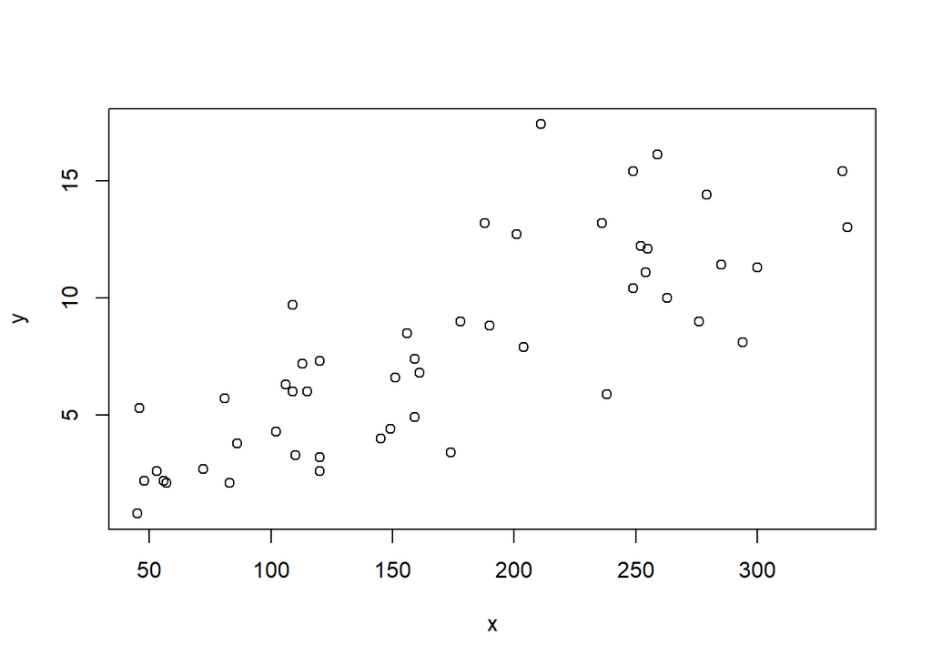

```r
plot(x,y)
```

1. Does this look like a reasonable dataset to fit a linear model to? Explain why or why not.
2. Regardless of your answer to part a, fit a linear model to this data. Show the summary print out with the full table of coefficients.
3. Does this result show a significant relation between x,y? Answer why or why not and give a p-value.
4. Give a 95% confidence interval for the true slope.
5. Make the standard diagnostic plot(s) for the residuals. Does this fit look reasonable? Explain why or why not.

> SOLUTION

Linear model fits well here; result shows significant relationship (p=2e-12). No sign of residual problems.

```r
lm1 = lm(y~x)
summary(lm1)
```

```
##
## Call:
## lm(formula = y ~ x)
##
## Residuals:
##     Min      1Q  Median      3Q     Max
## -4.8528 -1.7456 -0.3979  1.3044  7.9256
##
## Coefficients:
##             Estimate Std. Error t value Pr(>|t|)
## (Intercept) 0.631683   0.854776   0.739    0.464
## x           0.041909   0.004507   9.298  2.6e-12 ***
## ---
## Signif. codes:  0 '***' 0.001 '**' 0.01 '*' 0.05 '.' 0.1 ' ' 1
##
## Residual standard error: 2.629 on 48 degrees of freedom
## Multiple R-squared:  0.643,  Adjusted R-squared:  0.6356
## F-statistic: 86.45 on 1 and 48 DF,  p-value: 2.596e-12
```

```r
confint(lm1)
```

```
##                   2.5 %     97.5 %
## (Intercept) -1.08695906 2.35032438
## x            0.03284621 0.05097104
```

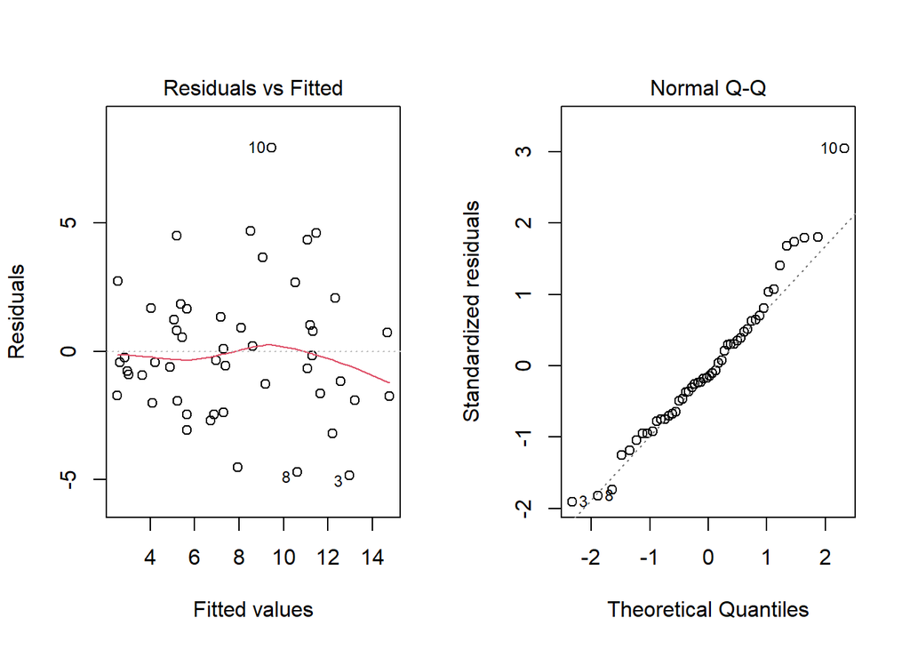

```r
par(mfrow=c(1,2))
plot(lm1,which=1:2)
```